# Dashboard – Análisis de Cáncer de Pulmón

Muestra analizada

276

Accuracy

92.6%

Sensibilidad

100.0%

Especificidad

42.9%

Objetivo del análisis

**Objetivo**

Analizar las características de personas con y sin cáncer de pulmón, identificar diferencias entre ambos grupos y evaluar el desempeño predictivo de un modelo Random Forest.

**Muestra analizada:** 276 observaciones luego de la limpieza.

**Metodología:** análisis exploratorio, comparación entre grupos, pruebas de asociación para variables categóricas y evaluación de un modelo Random Forest.

Distribución del diagnóstico

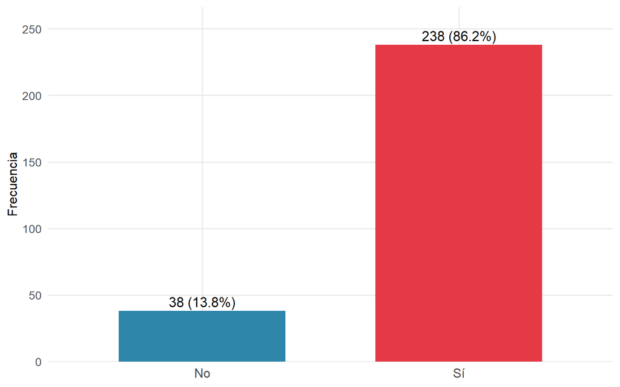

Edad según diagnóstico

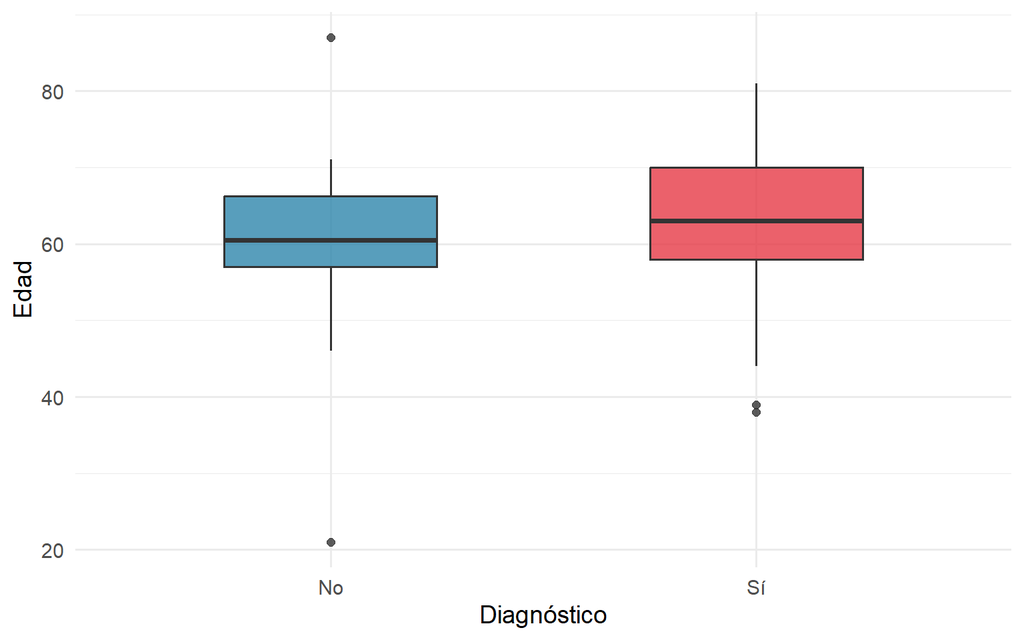

Distribución de la edad

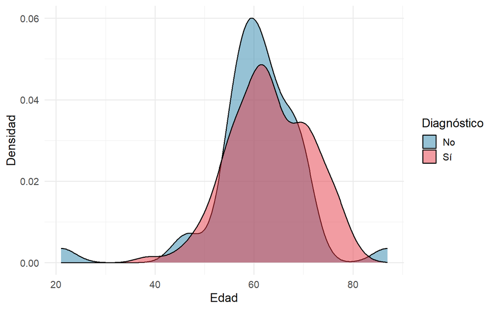

Histograma de la edad

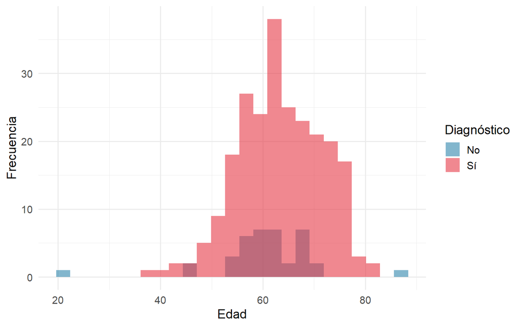

Edad, tabaquismo y diagnóstico

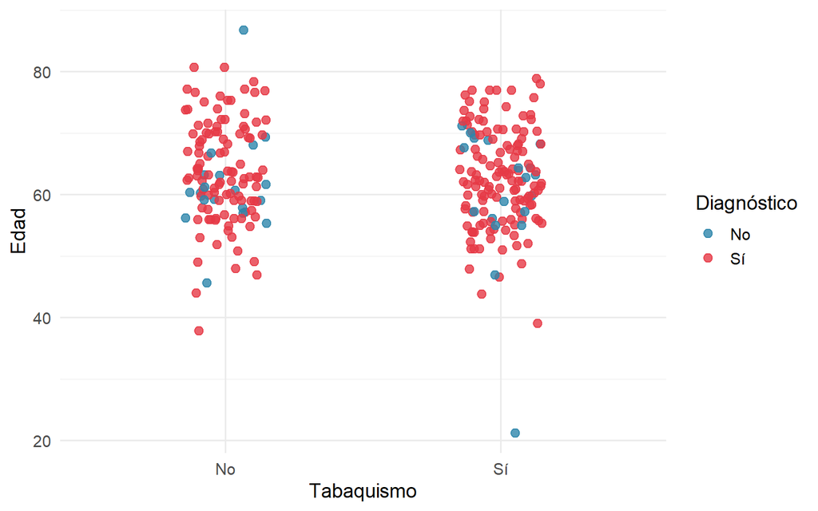

Sexo según diagnóstico

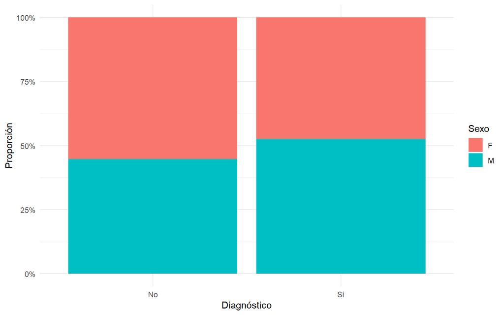

Porcentaje de respuestas afirmativas por variable y diagnóstico

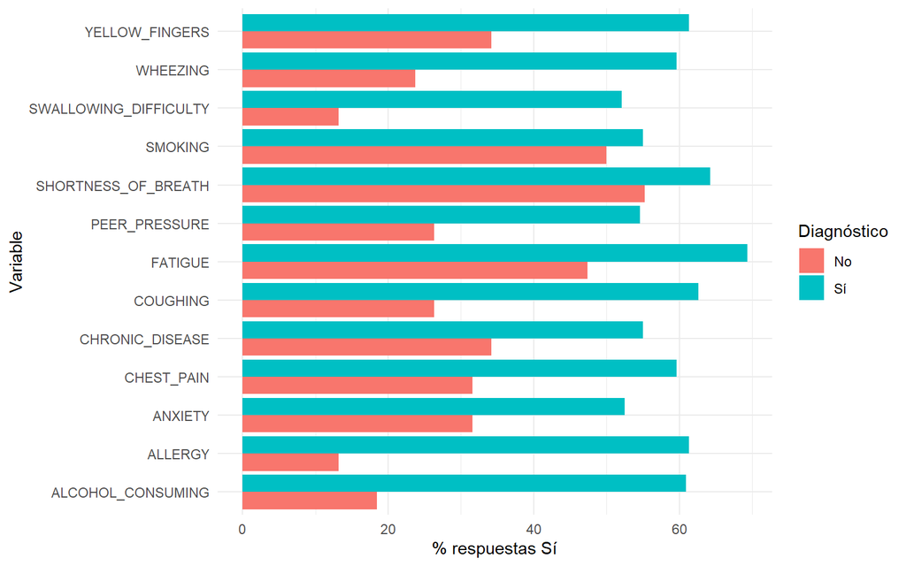

Pruebas de asociación (Chi-cuadrado / Fisher, ajuste BH)

| Variable | Prueba | Estadistico | p_valor | p_ajustado_BH |
| --- | --- | --- | --- | --- |
| GENDER | Chi-cuadrado | 0.7949 | 0.3726 | 0.4013 |
| SMOKING | Chi-cuadrado | 0.3358 | 0.5623 | 0.5623 |
| YELLOW_FINGERS | Chi-cuadrado | 9.8790 | 0.0017 | 0.0029 |
| ANXIETY | Chi-cuadrado | 5.7487 | 0.0165 | 0.0216 |
| PEER_PRESSURE | Chi-cuadrado | 10.5042 | 0.0012 | 0.0024 |
| CHRONIC_DISEASE | Chi-cuadrado | 5.6987 | 0.0170 | 0.0216 |
| FATIGUE | Chi-cuadrado | 7.0725 | 0.0078 | 0.0122 |
| ALLERGY | Chi-cuadrado | 30.7069 | 0.0000 | 0.0000 |
| WHEEZING | Chi-cuadrado | 17.1197 | 0.0000 | 0.0001 |
| ALCOHOL_CONSUMING | Chi-cuadrado | 23.9249 | 0.0000 | 0.0000 |
| COUGHING | Chi-cuadrado | 17.6703 | 0.0000 | 0.0001 |
| SHORTNESS_OF_BREATH | Chi-cuadrado | 1.1449 | 0.2846 | 0.3320 |
| SWALLOWING_DIFFICULTY | Chi-cuadrado | 19.9627 | 0.0000 | 0.0000 |
| CHEST_PAIN | Chi-cuadrado | 10.4794 | 0.0012 | 0.0024 |

Matriz de confusión (conjunto de prueba)

|  | No | Sí |
| --- | --- | --- |
| No | 3 | 0 |
| Sí | 4 | 47 |

Métricas del modelo

|  | Métrica | Valor |
| --- | --- | --- |
| Accuracy | Accuracy | 0.926 |
| Sensitivity | Sensibilidad | 1.000 |
| Specificity | Especificidad | 0.429 |
| Balanced Accuracy | Balanced Accuracy | 0.714 |
| Kappa | Kappa | 0.566 |

Importancia de variables (Random Forest)

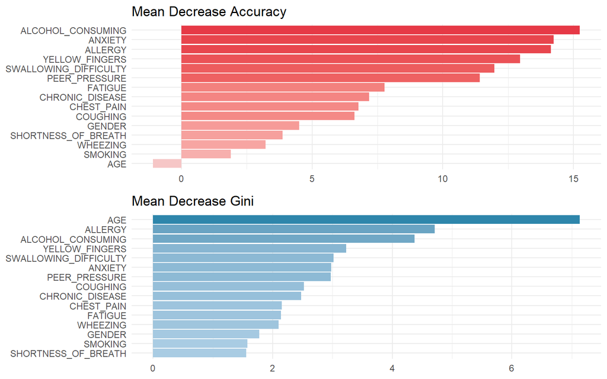

Tabla de importancia de variables

| Variable | No | Sí | MeanDecreaseAccuracy | MeanDecreaseGini |
| --- | --- | --- | --- | --- |
| AGE | -0.853 | -0.539 | -1.080 | 7.134 |
| ALLERGY | 17.163 | 3.648 | 14.140 | 4.706 |
| ALCOHOL_CONSUMING | 13.419 | 9.916 | 15.239 | 4.371 |
| YELLOW_FINGERS | 6.262 | 11.578 | 12.958 | 3.227 |
| SWALLOWING_DIFFICULTY | 10.512 | 6.891 | 11.980 | 3.017 |
| ANXIETY | 7.591 | 12.454 | 14.249 | 2.976 |
| PEER_PRESSURE | 8.141 | 8.587 | 11.419 | 2.974 |
| COUGHING | 7.475 | 1.734 | 6.626 | 2.524 |
| CHRONIC_DISEASE | 3.618 | 6.470 | 7.180 | 2.474 |
| CHEST_PAIN | 7.876 | 1.839 | 6.776 | 2.155 |
| FATIGUE | 7.308 | 4.841 | 7.778 | 2.141 |
| WHEEZING | 5.689 | -0.673 | 3.229 | 2.097 |
| GENDER | 3.943 | 2.463 | 4.511 | 1.773 |
| SMOKING | 1.133 | 1.568 | 1.887 | 1.576 |
| SHORTNESS_OF_BREATH | 5.241 | 0.607 | 3.871 | 1.555 |

**ImportantDesempeño del modelo**

El modelo Random Forest alcanzó una **sensibilidad del 100%** pero una **especificidad de apenas 42,9%**, explicado por el marcado desbalance de clases (predominan los casos positivos en la muestra).

**NoteEdad y diagnóstico**

La comparación de la edad entre grupos **no mostró diferencias estadísticamente significativas** (Mann-Whitney, p = 0,1095).

**TipVariables asociadas al diagnóstico**

YELLOW_FINGERS, ANXIETY, PEER_PRESSURE, CHRONIC_DISEASE, FATIGUE, ALLERGY, WHEEZING, ALCOHOL_CONSUMING, COUGHING, SWALLOWING_DIFFICULTY y CHEST_PAIN mostraron **asociación significativa** con el diagnóstico tras la corrección de Benjamini-Hochberg.

**WarningLimitaciones**

Los resultados corresponden a una única base de datos y **no constituyen una validación clínica** del modelo. La importancia de variables no implica causalidad.